# Part 2: More advanced big data integration with Spark

# Sparkly

- Some general guidelines: If the size of data is less than 25% of computer RAM, R should generally be comfortable to process. When the size is about 50% of RAM, `data.table` should be still fine. When the size is about 50% – 75% of RAM, it is worth trying `sparklyr`.

## Set up running environment

To set up a running environment for allowing Spark connection to a file, `sparklyr` library needs to be loaded and configured.

Run the following configuration to complete setup.

```r
library(sparklyr)
library(dplyr)
library(ggplot2)
library(zoo)
```

```r
# Initialize configuration with default settings
config <- spark_config()

# Setup memory
config$`sparklyr.shell.driver-memory` <- "4G"
config$`sparklyr.shell.executor-memory` <- "8G"
config$`spark.yarn.executor.memoryOverhead` <- "4G"

# Connnect to local cluster with the configuration given above
sc <- spark_connect(master = "local", config = config)
```

```
* Using Spark: 3.3.0
```

- For more details please check [here](https://therinspark.com/tuning.html).

**General Guidelines**:

Leave Memory for the OS: Reserve around 2-4GB for the operating system and other applications.

Allocate Memory for Driver (shell.driver-memory) and Executors (shell.executor-memory): Divide the remaining memory between the driver and executors.

Example Configuration: Assuming you have 16GB RAM in total, reserve 4GB for the OS, and leave 12GB available for Spark. You can then allocate memory as follows:

Driver Memory: Allocate around 4GB to the driver. Executor Memory: Allocate the remaining 8GB to the executors.

Optional: the yarn.executor.memoryOverhead configuration in Spark specifies the amount of additional memory allocated per executor process.

## Set connection to the CSV data

```r
compustat <- spark_read_csv(sc, "~/Downloads/computstat_gbr_2014_2024.csv")
```

## Sparklyr exercises

### Exercise 2.1 Check data length

- Find the number of rows of data

```r
sdf_nrow(compustat)
```

```
[1] 6711449
```

### Exercise 2.2 Select a subset

- Select a subject contains British American Tobacco with iid as 01W.

```r
BAT_01W <- compustat %>%
    filter(conm == "BRITISH AMER TOBACCO PLC" , iid == "01W")
```

- Plot the close price “prccd” of the stock of British American Tobacco

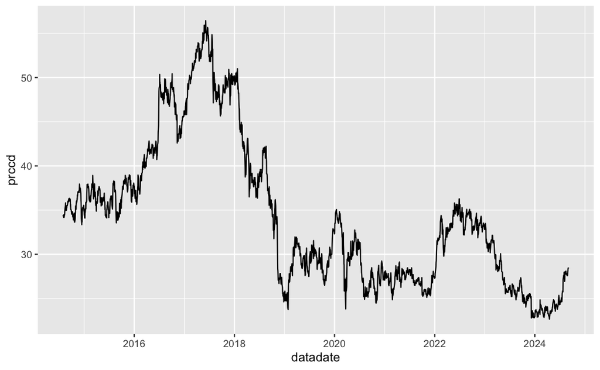

```r
ggplot(BAT_01W, aes(x = datadate, y=prccd)) + geom_line()
```

### Exercise 2.3 Add new column(s)

- Add a new column `YearQ` for holding year and quarters information.

```r
BAT_01W<-BAT_01W %>%
  mutate(YearQ=paste(year(datadate), quarter(datadate)))
```

### Exercise 2.4 Calculate simple daily returns.

- Use the following equation to calculate simple daily returns.

$$returns_t = \frac{prccd_t}{prccd_{t-1}}
- 1$$
.

```r
compustat1 <- compustat %>%
  group_by(gvkey, iid, conm) %>%
  arrange(datadate) %>%
  mutate(daily_returns = prccd/lag(prccd) - 1) %>%
  ungroup()
```

### Exercise 2.5 Summarise

- Summarise the mean values and SD of close price (`prccd`).

```r
mean_close <- compustat %>%
  filter(!is.na(prccd)) %>%
  group_by(gvkey, iid, conm) %>%
  summarise(mean_prccd = mean(prccd), sd_prccd = sd(prccd)) %>%
  ungroup() %>%
  collect()
```

### Exercise 2.6 Outlier detection

```r
quantile_stats <- BAT %>%
  select(daily_returns) %>%
  collect() %>%
  quantile(., probs = c(0, 0.25, 0.5, 0.75, 1), na.rm = T)


# Check collected stats
print(quantile_stats)

# Calculate IQR and bounds in R
q1 <- quantile_stats[2]
q3 <- quantile_stats[4]
iqr_val <- q3 - q1
lower_bound <- as.numeric(q1 - 1.5 * iqr_val)
upper_bound <- as.numeric(q3 + 1.5 * iqr_val)

print(paste("Lower Bound (IQR Method):", lower_bound))
print(paste("Upper Bound (IQR Method):", upper_bound))

BAT_outliers <- BAT %>%
  mutate(is_outliers = ifelse(daily_returns < lower_bound | daily_returns > upper_bound, 1, 0))
```

[output not shown]

### Exercise 2.7 Clustering

- Use `ml_kmeans()` to cluster simple daily returns of “BRITISH AMER TOBACCO PLC”.

```r
centroids_tbl <- ml_centers(kmeans_model)
```

[output not shown]

### Exercise 2.8 Clustering with multiple columns

- Use `ml_kmeans()` to cluster `prccd`, `prchd`, `prcld` of “BRITISH AMER TOBACCO PLC”.

```r
# Vectorize the features
compustat_scaled <- BAT %>%
  ft_vector_assembler(input_cols = c("prccd"), output_col = "prccd_vec") %>%
  ft_vector_assembler(input_cols = c("prchd"), output_col = "prchd_vec") %>%
  ft_vector_assembler(input_cols = c("prcld"), output_col = "prcld_vec") %>%
  ft_standard_scaler(input_col = "prccd_vec", output_col = "prccd_scaled") %>%
  ft_standard_scaler(input_col = "prchd_vec", output_col = "prchd_scaled") %>%
  ft_standard_scaler(input_col = "prcld_vec", output_col = "prcld_scaled")
```

### Exercise 2.9 Correlation of close price

- Use `ml_corr` to work out correlation of `prccd` from “BRITISH AMER TOBACCO PLC” and “GOODWIN PLC”.

```r
wide_tbl_renamed_corr <- wide_tbl_renamed %>%
  ml_corr(columns = c("BAT_prccd", "GOODWIN_prccd"), method = "pearson")
```

## Part 2 ends.